# Social media reliance and misinformation beliefs

Dipankar Lahiri

2025-03-06

Regression models indicate that age and social media reliance are key predictors of misinformation beliefs, with older individuals and those less reliant on Facebook holding lower beliefs.

[figure not shown]

This is an analysis of a random sample dataframe of 500 individuals on the basis of four variables:

1. Age (ratio data) - Participants were asked for their age at their last birthday.
2. Gender (nominal data) - Participants were asked whether they identified as ‘Male’, ‘Female’, or ‘In another way’.
3. Knowledge about coronavirus through Facebook (ordinal data) - Answers to the question: ‘Please tell us how much of what you know about coronavirus, if anything, comes from Facebook’. Answer options were: ‘Nothing at all’, ‘Not very much’, ‘A fair amount’, ‘A great deal’, and ‘Don’t know’.
4. Number of misinformation beliefs (ratio data) - Number of the following statements which the respondent considers true (options for each were ‘True’, ‘False’, and ‘Don’t know’):
- Coronavirus was probably created in a laboratory
- The symptoms that most people blame on coronavirus appear to be linked to 5G network radiation
- There is no hard evidence that coronavirus really exists
- The number of people reported as dying from coronavirus is being deliberately exaggerated by the authorities
- The current pandemic is part of a global effort to force everyone to be vaccinated whether they want to or not

## Descriptive Statistics Analysis & Visualisation

### Age

```
##    Min. 1st Qu.  Median    Mean 3rd Qu.    Max.
##   16.00   30.00   44.00   44.57   58.00   75.00
```

```
## [1] 16.42659
```

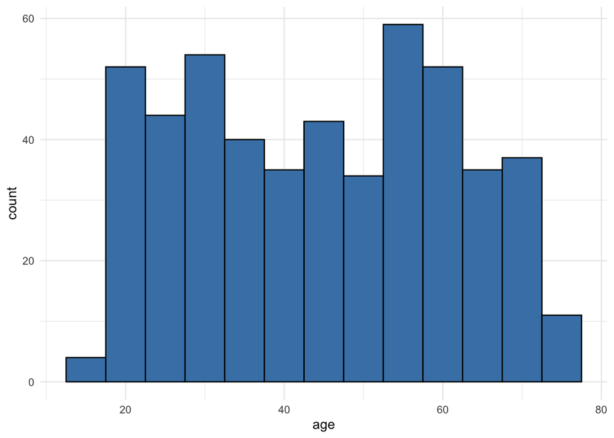

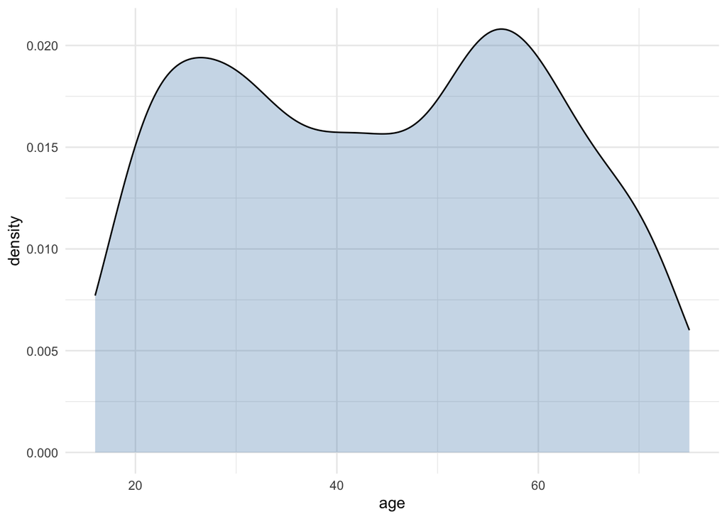

The ages in our sample range from 16 to 75, with a mean age of 44.57 and a median age of 44, indicating a nearly symmetrical distribution. The standard deviation (16.43) suggests a moderate spread of ages around the mean.

A skewness of 0.02 confirms the distribution is almost symmetric, while a kurtosis of 1.77 suggests a platykurtic shape — a flatter distribution with fewer extreme outliers than a normal distribution. A density plot shows that individuals in their 20s and 50s are the most represented age groups.

### Gender

```
## # A tibble: 3 × 3
##   gender             n percentage
##   <chr>          <int>      <dbl>
## 1 Female           247       49.4
## 2 In another way     2        0.4
## 3 Male             251       50.2
```

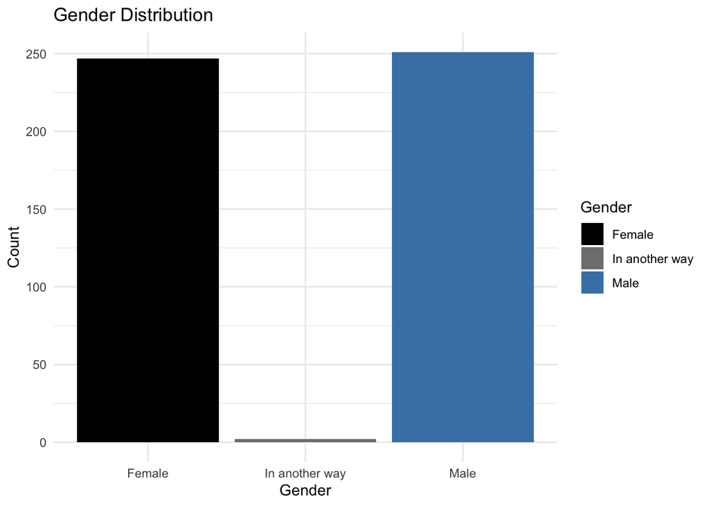

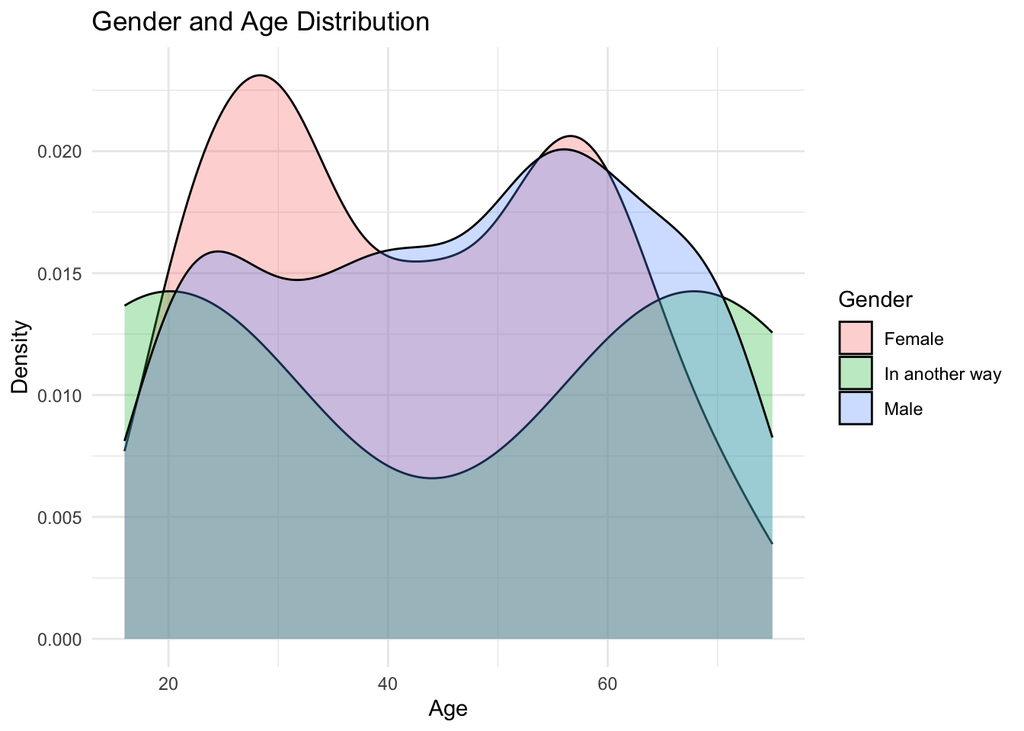

There are 247 females (49.4%), 251 males (50.2%) and 2 people who identify in another way (0.4%) in our sample. A density plot shows that women outnumber men in the 20-40 age range in our sample, while men outnumber women in the 40-50 and 60+ age ranges.

### Reliance on Facebook for Covid info

```
## # A tibble: 4 × 3
##   know_facebook      n percentage
##   <ord>          <int>      <dbl>
## 1 Nothing at all   248       49.6
## 2 Not very much    148       29.6
## 3 A fair amount     73       14.6
## 4 A great deal      31        6.2
```

```
## [1] 2
```

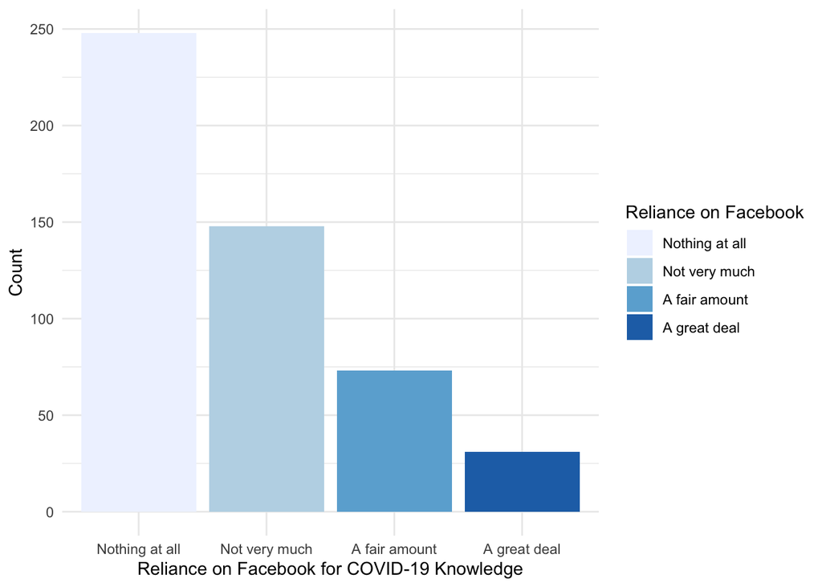

In our sample, 49.6% of respondents get none of their coronavirus information from Facebook, 29.6% get not much, 14.6% get a fair amount, and 6.2% get a great deal. The median response is ‘Not very much,’ indicating that most people rely only minimally on Facebook for information.

#### Age & Gender’s Associations with Reliance on Facebook

**Gender vs Reliance on Facebook**

```
## # A tibble: 9 × 4
## # Groups:   gender [3]
##   gender         know_facebook      n percentage
##   <chr>          <ord>          <int>      <dbl>
## 1 Female         Nothing at all   118      47.8
## 2 Female         Not very much     77      31.2
## 3 Female         A fair amount     37      15.0
## 4 Female         A great deal      15       6.07
## 5 In another way Nothing at all     2     100
## 6 Male           Nothing at all   128      51.0
## 7 Male           Not very much     71      28.3
## 8 Male           A fair amount     36      14.3
## 9 Male           A great deal      16       6.37
```

```
##
##  Pearson's Chi-squared test with simulated p-value (based on 2000 replicates)
##
## data:  table(my_df$gender, my_df$know_facebook)
## X-squared = 2.7046, df = NA, p-value = 0.8566
```

The high p-value (p > 0.05) suggests that there is no statistically significant association between gender and knowledge of Facebook. The observed differences in counts are likely due to random variation rather than a meaningful relationship.

**Age vs Reliance on Facebook**

[figure not shown]

```
## # A tibble: 4 × 2
##   know_facebook  median_age
##   <ord>               <dbl>
## 1 Nothing at all       53.5
## 2 Not very much        41.5
## 3 A fair amount        35
## 4 A great deal         30
```

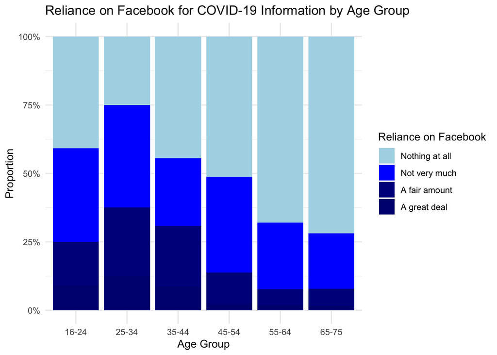

```
## [1] -0.3022986
```

### Misinformation Beliefs

```
##    Min. 1st Qu.  Median    Mean 3rd Qu.    Max.
##   0.000   0.000   0.000   0.668   1.000   5.000
```

```
## [1] 1.095526
```

```
## # A tibble: 6 × 3
##   beliefs     n percentage
##     <dbl> <int>      <dbl>
## 1       0   308       61.6
## 2       1   116       23.2
## 3       2    38        7.6
## 4       3    18        3.6
## 5       4    12        2.4
## 6       5     8        1.6
```

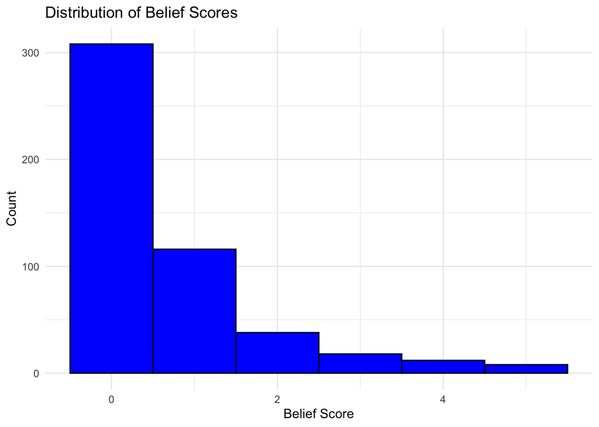

The belief scores are highly right-skewed (skewness = 2.02) and peaked (kurtosis = 6.99), indicating most respondents rejected most statements, with a few endorsing multiple. Since the skewness is greater than 0, the distribution has a long tail on the right, meaning a small number of people have high belief scores while most people have low scores (close to 0). The median score is 0, and the mean (0.67) is slightly higher, suggesting a concentration of low scores with some extreme values at the higher end.

A proportion distribution of belief scores shows 308 people (61.6%) rejected all five statements, 116 people (23.2%) rejected most but endorsed one, 38 people (7.6%) endorsed two statements, 18 people (3.6%) endorsed three, 12 people (2.4%) endorsed four, and 8 people (1.6%) endorsed all five statements.

#### Associations of Misinformation Beliefs with Age, Gender, Reliance on FB

**Gender vs Misinformation Beliefs**

```
## # A tibble: 3 × 5
##   gender             n     M   Mdn    SD
##   <chr>          <int> <dbl> <dbl> <dbl>
## 1 Female           247 0.607     0  1.05
## 2 In another way     2 1         1  1.41
## 3 Male             251 0.725     0  1.13
```

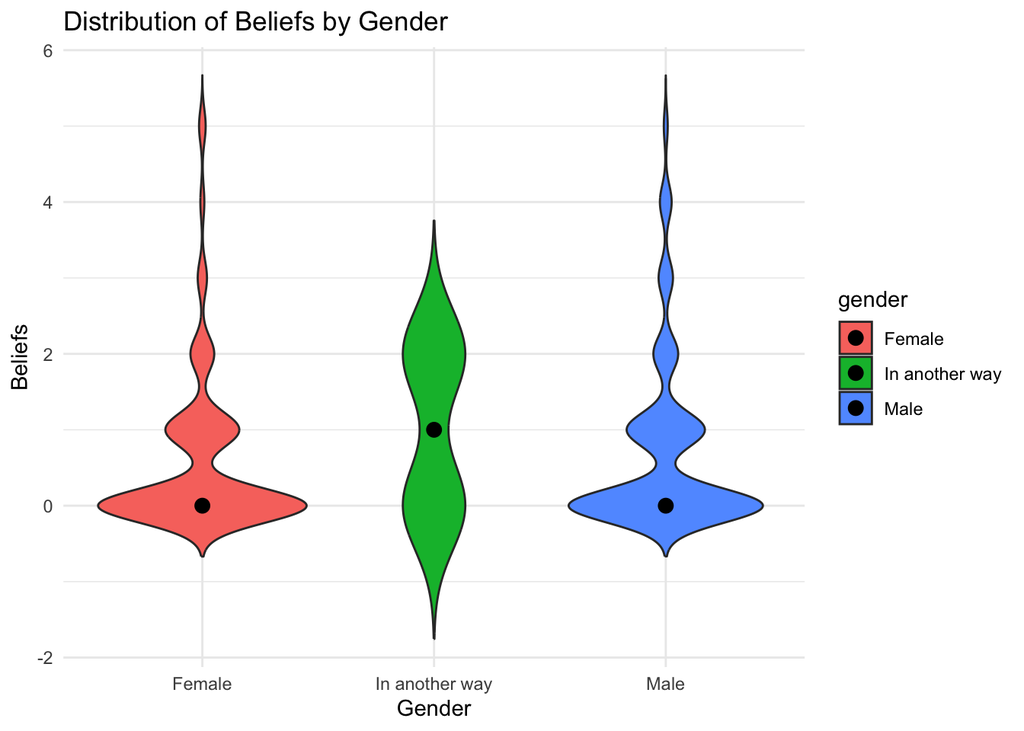

```
##
##  Welch Two Sample t-test
##
## data:  beliefs by gender
## t = -1.201, df = 494.31, p-value = 0.2303
## alternative hypothesis: true difference in means between group Female and group Male is not equal to 0
## 95 percent confidence interval:
##  -0.31055434  0.07493004
## sample estimates:
## mean in group Female   mean in group Male
##            0.6072874            0.7250996
```

```
##
##  Wilcoxon rank sum test with continuity correction
##
## data:  beliefs by gender
## W = 29340, p-value = 0.2341
## alternative hypothesis: true location shift is not equal to 0
```

In the sample, men (M = 0.73, SD = 1.13) have more misinformation beliefs than women (M = 0.61, SD = 1.05). However, this difference is not statistically significant, as shown by both a Welch t-test, t(494.31) = -1.20, p = 0.230, and a Wilcoxon rank-sum test, W = 29,340, p = 0.234. This suggests that gender does not play a significant role in misinformation beliefs. The violin plot visualizes this comparison, showing a largely overlapping distribution of beliefs between men and women.

**Age vs Misinformation Beliefs**

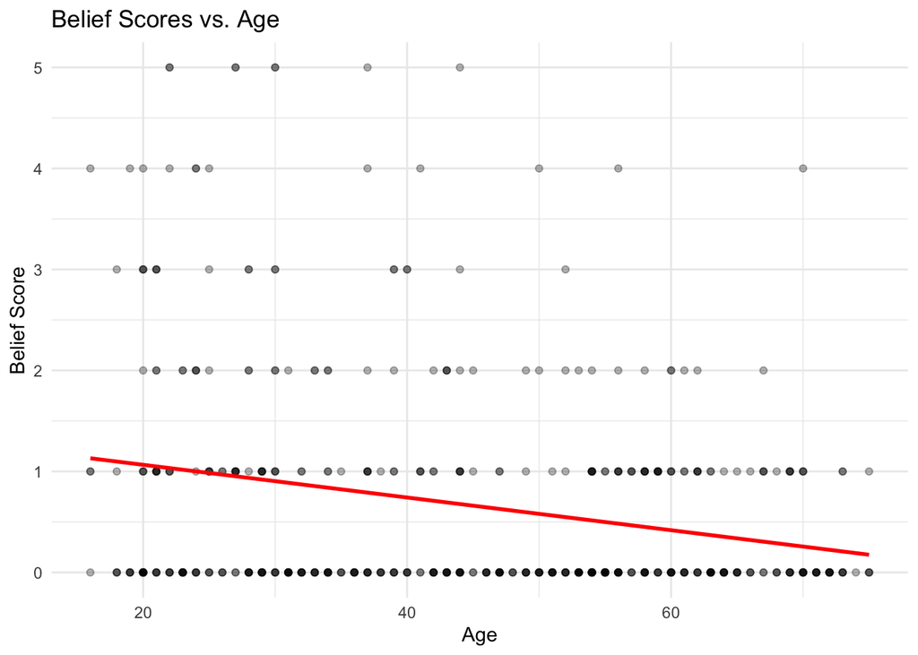

```
##
##  Pearson's product-moment correlation
##
## data:  my_df$beliefs and my_df$age
## t = -5.5829, df = 498, p-value = 0.00000003893
## alternative hypothesis: true correlation is not equal to 0
## 95 percent confidence interval:
##  -0.3235017 -0.1583759
## sample estimates:
##       cor
## -0.242696
```

Younger individuals tend to have higher misinformation beliefs, as indicated by a weak but statistically significant negative correlation between age and belief scores (r = -0.24, p < 0.001). A Pearson correlation test (t(498) = -5.58, p < 0.001, 95% CI [-0.32, -0.16]) suggests that as age increases, misinformation beliefs decrease slightly.

**Reliance on FB vs Misinformation Beliefs**

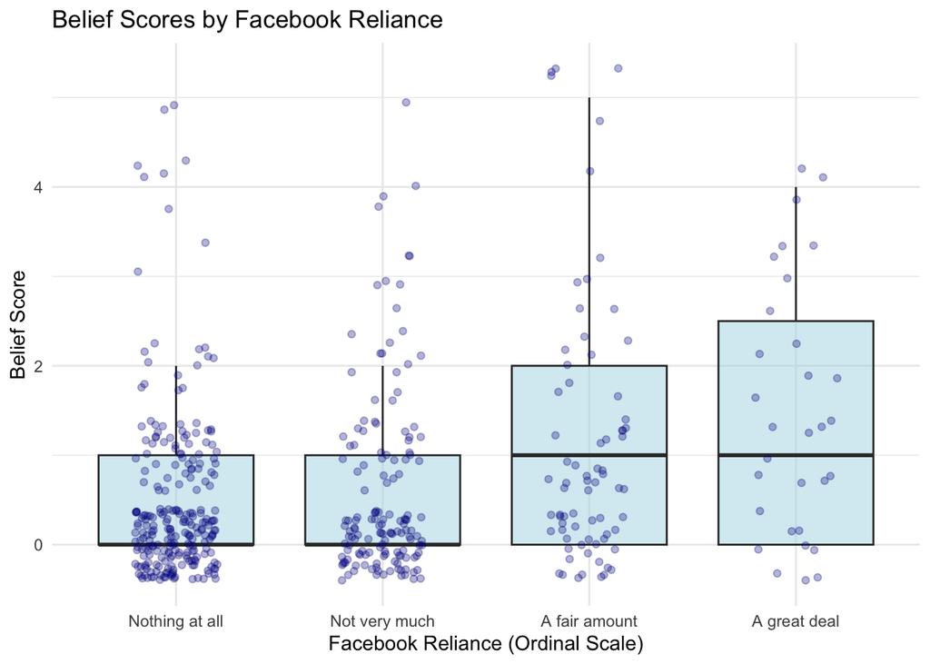

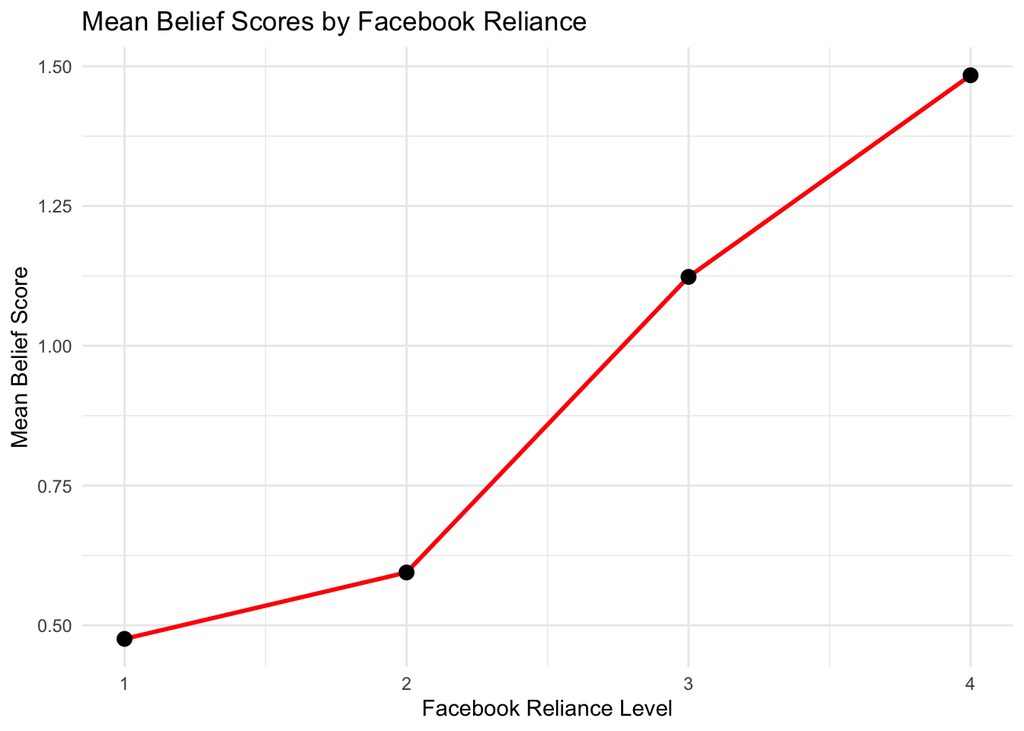

```
##
##  Spearman's rank correlation rho
##
## data:  my_df$beliefs and as.numeric(my_df$know_facebook)
## S = 16061316, p-value = 0.0000002243
## alternative hypothesis: true rho is not equal to 0
## sample estimates:
##       rho
## 0.2290537
```

Reliance on Facebook for coronavirus information is positively correlated with belief scores (rho = 0.23, p < 0.001), meaning those who rely more on Facebook tend to believe more misinformation statements. This correlation is also weak but statistically significant.

The boxplot above shows a high concentration of 0 misinformation beliefs for those who do not get much information from Facebook, and no such concentration of values for those who do get information from Facebook. The line graph indicates a positive trend, with mean misinformation beliefs rising as Facebook reliance increases.

## Linear Regression to Predict Misinformation Beliefs

#### Age

```
##
## Call:
## lm(formula = beliefs ~ age, data = .)
##
## Residuals:
##     Min      1Q  Median      3Q     Max
## -1.1304 -0.6934 -0.3697  0.4846  4.3228
##
## Coefficients:
##              Estimate Std. Error t value             Pr(>|t|)
## (Intercept)  1.389407   0.137698  10.090 < 0.0000000000000002 ***
## age         -0.016186   0.002899  -5.583         0.0000000389 ***
## ---
## Signif. codes:  0 '***' 0.001 '**' 0.01 '*' 0.05 '.' 0.1 ' ' 1
##
## Residual standard error: 1.064 on 498 degrees of freedom
## Multiple R-squared:  0.0589, Adjusted R-squared:  0.05701
## F-statistic: 31.17 on 1 and 498 DF,  p-value: 0.00000003893
```

There is a statistically significant negative relationship between age and misinformation beliefs (β=−0.016,p<0.001). The regression model, Beliefs = 1.389 − 0.016 × Age, suggests that for each additional year of age, the belief score decreases by 0.016 on average. However, the model explains only 5.89% of the variance in misinformation beliefs (R-squared = 0.0589), indicating that age alone is not a strong predictor.

#### Gender

```
##
## Call:
## lm(formula = beliefs ~ Female, data = .)
##
## Residuals:
##     Min      1Q  Median      3Q     Max
## -0.7273 -0.7273 -0.6073  0.3927  4.3927
##
## Coefficients:
##             Estimate Std. Error t value            Pr(>|t|)
## (Intercept)  0.72727    0.06884  10.565 <0.0000000000000002 ***
## Female      -0.11999    0.09794  -1.225               0.221
## ---
## Signif. codes:  0 '***' 0.001 '**' 0.01 '*' 0.05 '.' 0.1 ' ' 1
##
## Residual standard error: 1.095 on 498 degrees of freedom
## Multiple R-squared:  0.003004,   Adjusted R-squared:  0.001002
## F-statistic: 1.501 on 1 and 498 DF,  p-value: 0.2211
```

There is no statistically significant relationship between gender and misinformation beliefs (β = -0.120, p = 0.221). The regression model, Beliefs = 0.727 − 0.120 × Female, indicates that when Female = 0 (i.e., men), the expected belief score is 0.727, whereas when Female = 1 (i.e., women), the expected belief score is 0.608. This suggests that women, on average, have 0.120 lower belief scores than men, but this difference is not statistically meaningful. The model explains only 0.3% of the variance in misinformation beliefs (R-squared = 0.003), indicating that gender is not a strong predictor.

#### Facebook Reliance

```
##
## Call:
## lm(formula = beliefs ~ High_Facebook, data = .)
##
## Residuals:
##     Min      1Q  Median      3Q     Max
## -1.2308 -0.5202 -0.5202  0.4798  4.4798
##
## Coefficients:
##               Estimate Std. Error t value             Pr(>|t|)
## (Intercept)    0.52020    0.05316   9.786 < 0.0000000000000002 ***
## High_Facebook  0.71057    0.11656   6.096        0.00000000218 ***
## ---
## Signif. codes:  0 '***' 0.001 '**' 0.01 '*' 0.05 '.' 0.1 ' ' 1
##
## Residual standard error: 1.058 on 498 degrees of freedom
## Multiple R-squared:  0.06944,    Adjusted R-squared:  0.06757
## F-statistic: 37.16 on 1 and 498 DF,  p-value: 0.00000000218
```

There is a statistically significant positive relationship between high reliance on Facebook for COVID-19 information and misinformation beliefs (β = 0.711, p < 0.001). The regression model, Beliefs = 0.520 + 0.711 × High_Facebook, suggests that individuals who rely more on Facebook have, on average, 0.711 higher belief scores than those with lower reliance. However, the model explains only 6.94% of the variance in misinformation beliefs (R-squared = 0.0694), indicating that Facebook reliance alone is a weak predictor.

#### Multiple Linear Regression

```
##
## Call:
## lm(formula = beliefs ~ age + High_Facebook + Female, data = .)
##
## Residuals:
##     Min      1Q  Median      3Q     Max
## -1.5357 -0.6411 -0.3292  0.5180  4.3061
##
## Coefficients:
##                Estimate Std. Error t value           Pr(>|t|)
## (Intercept)    1.218768   0.157691   7.729 0.0000000000000608 ***
## age           -0.013202   0.002932  -4.502 0.0000083826415771 ***
## High_Facebook  0.581005   0.117903   4.928 0.0000011353268187 ***
## Female        -0.168392   0.093311  -1.805             0.0717 .
## ---
## Signif. codes:  0 '***' 0.001 '**' 0.01 '*' 0.05 '.' 0.1 ' ' 1
##
## Residual standard error: 1.037 on 496 degrees of freedom
## Multiple R-squared:  0.109,  Adjusted R-squared:  0.1037
## F-statistic: 20.23 on 3 and 496 DF,  p-value: 0.000000000002192
```

When all three predictors are included together, the model is: **Beliefs = 1.219 - 0.013 × Age + 0.581 × High_Facebook - 0.168 × Female**

**Age:** The negative relationship remains significant but weakens from -0.016 to -0.013. This means age is still associated with lower misinformation beliefs, but its impact slightly decreases when controlling for other factors.

**High Facebook Reliance:** The effect size decreases from 0.711 to 0.581, meaning that while high Facebook use remains a strong predictor, part of its influence may be shared with other variables, like Age.

**Gender:** The negative effect of being Female becomes slightly stronger (-0.120 to -0.168) but remains statistically insignificant (p = 0.072). This suggests that once age and Facebook reliance are accounted for, women might have even lower misinformation beliefs, but the effect is still not strong enough to be statistically significant.

The full model explains 10.9% of the variance in misinformation beliefs (R-squared = 0.109), which is higher than any of the individual models but still low overall.